# Project 2

Coffee Review Visualizations

**Group Number: 25**

**We, Aashutosh Sehgal, Iman Fatima, Jasmine, Rubaldeep Kaur and Umair Nabeel, hereby state that we have not communicated with or gained** **information in any way from any person or resource that would violate the College’s academic integrity policies, and that all work** **presented is our own. In addition, we also agree not to share our work in any way, before or after submission, that would violate the** **College’s academic integrity policies.**

**R & RStudio Version:**

- 4.0.5 (2021-03-31)
- 1.4.1106

**Packages and their versions:**

- Tidyverse (1.3.1)
- Ggplot2 (3.3.3)
- Skimr (2.1.3)
- Patchwork (1.1.1)
- Pander (0.6.4)
- GGridges (0.5.3)
- Viridis (0.6.1)
- Hrbrthemes (0.8.0)
- RColorBrewer (1.1.2)

# NOTE

### The plots have been arranged in alphabetical order of authors names for both Univariate and Bivariate.

# Loading Data

```r
library(tidyverse)
library(patchwork)
library(pander)
library(ggridges)
library(viridis)
library(hrbrthemes)
library(RColorBrewer)

coffee_ratings <- readr::read_csv(
  'https://raw.githubusercontent.com/rfordatascience/tidytuesday/master/data/2020/2020-07-07/coffee_ratings.csv'
  )
```

```r
library(skimr)

skim(coffee_ratings)
```

Table 1: Data summary

| Name | coffee_ratings |
| --- | --- |
| Number of rows | 1339 |
| Number of columns | 43 |
| _______________________ |  |
| Column type frequency: |  |
| character | 24 |
| numeric | 19 |
| ________________________ |  |
| Group variables | None |

**Variable type: character**

| skim_variable | n_missing | complete_rate | min | max | empty | n_unique | whitespace |
| --- | --- | --- | --- | --- | --- | --- | --- |
| species | 0 | 1.00 | 7 | 7 | 0 | 2 | 0 |
| owner | 7 | 0.99 | 3 | 50 | 0 | 315 | 0 |
| country_of_origin | 1 | 1.00 | 4 | 28 | 0 | 36 | 0 |
| farm_name | 359 | 0.73 | 1 | 73 | 0 | 571 | 0 |
| lot_number | 1063 | 0.21 | 1 | 71 | 0 | 227 | 0 |
| mill | 315 | 0.76 | 1 | 77 | 0 | 460 | 0 |
| ico_number | 151 | 0.89 | 1 | 40 | 0 | 847 | 0 |
| company | 209 | 0.84 | 3 | 73 | 0 | 281 | 0 |
| altitude | 226 | 0.83 | 1 | 41 | 0 | 396 | 0 |
| region | 59 | 0.96 | 2 | 76 | 0 | 356 | 0 |
| producer | 231 | 0.83 | 1 | 100 | 0 | 691 | 0 |
| bag_weight | 0 | 1.00 | 1 | 8 | 0 | 56 | 0 |
| in_country_partner | 0 | 1.00 | 7 | 85 | 0 | 27 | 0 |
| harvest_year | 47 | 0.96 | 3 | 24 | 0 | 46 | 0 |
| grading_date | 0 | 1.00 | 13 | 20 | 0 | 567 | 0 |
| owner_1 | 7 | 0.99 | 3 | 50 | 0 | 319 | 0 |
| variety | 226 | 0.83 | 4 | 21 | 0 | 29 | 0 |
| processing_method | 170 | 0.87 | 5 | 25 | 0 | 5 | 0 |
| color | 218 | 0.84 | 4 | 12 | 0 | 4 | 0 |
| expiration | 0 | 1.00 | 13 | 20 | 0 | 566 | 0 |
| certification_body | 0 | 1.00 | 7 | 85 | 0 | 26 | 0 |
| certification_address | 0 | 1.00 | 40 | 40 | 0 | 32 | 0 |
| certification_contact | 0 | 1.00 | 40 | 40 | 0 | 29 | 0 |
| unit_of_measurement | 0 | 1.00 | 1 | 2 | 0 | 2 | 0 |

**Variable type: numeric**

| skim_variable | n_missing | complete_rate | mean | sd | p0 | p25 | p50 | p75 | p100 | hist |
| --- | --- | --- | --- | --- | --- | --- | --- | --- | --- | --- |
| total_cup_points | 0 | 1.00 | 82.09 | 3.50 | 0 | 81.08 | 82.50 | 83.67 | 90.58 | ▁▁▁▁▇ |
| number_of_bags | 0 | 1.00 | 154.18 | 129.99 | 0 | 14.00 | 175.00 | 275.00 | 1062.00 | ▇▇▁▁▁ |
| aroma | 0 | 1.00 | 7.57 | 0.38 | 0 | 7.42 | 7.58 | 7.75 | 8.75 | ▁▁▁▁▇ |
| flavor | 0 | 1.00 | 7.52 | 0.40 | 0 | 7.33 | 7.58 | 7.75 | 8.83 | ▁▁▁▁▇ |
| aftertaste | 0 | 1.00 | 7.40 | 0.40 | 0 | 7.25 | 7.42 | 7.58 | 8.67 | ▁▁▁▁▇ |
| acidity | 0 | 1.00 | 7.54 | 0.38 | 0 | 7.33 | 7.58 | 7.75 | 8.75 | ▁▁▁▁▇ |
| body | 0 | 1.00 | 7.52 | 0.37 | 0 | 7.33 | 7.50 | 7.67 | 8.58 | ▁▁▁▁▇ |
| balance | 0 | 1.00 | 7.52 | 0.41 | 0 | 7.33 | 7.50 | 7.75 | 8.75 | ▁▁▁▁▇ |
| uniformity | 0 | 1.00 | 9.83 | 0.55 | 0 | 10.00 | 10.00 | 10.00 | 10.00 | ▁▁▁▁▇ |
| clean_cup | 0 | 1.00 | 9.84 | 0.76 | 0 | 10.00 | 10.00 | 10.00 | 10.00 | ▁▁▁▁▇ |
| sweetness | 0 | 1.00 | 9.86 | 0.62 | 0 | 10.00 | 10.00 | 10.00 | 10.00 | ▁▁▁▁▇ |
| cupper_points | 0 | 1.00 | 7.50 | 0.47 | 0 | 7.25 | 7.50 | 7.75 | 10.00 | ▁▁▁▇▁ |
| moisture | 0 | 1.00 | 0.09 | 0.05 | 0 | 0.09 | 0.11 | 0.12 | 0.28 | ▃▇▅▁▁ |
| category_one_defects | 0 | 1.00 | 0.48 | 2.55 | 0 | 0.00 | 0.00 | 0.00 | 63.00 | ▇▁▁▁▁ |
| quakers | 1 | 1.00 | 0.17 | 0.83 | 0 | 0.00 | 0.00 | 0.00 | 11.00 | ▇▁▁▁▁ |
| category_two_defects | 0 | 1.00 | 3.56 | 5.31 | 0 | 0.00 | 2.00 | 4.00 | 55.00 | ▇▁▁▁▁ |
| altitude_low_meters | 230 | 0.83 | 1750.71 | 8669.44 | 1 | 1100.00 | 1310.64 | 1600.00 | 190164.00 | ▇▁▁▁▁ |
| altitude_high_meters | 230 | 0.83 | 1799.35 | 8668.81 | 1 | 1100.00 | 1350.00 | 1650.00 | 190164.00 | ▇▁▁▁▁ |
| altitude_mean_meters | 230 | 0.83 | 1775.03 | 8668.63 | 1 | 1100.00 | 1310.64 | 1600.00 | 190164.00 | ▇▁▁▁▁ |

# Univariate Analysis

### For numeric variable, we will be using Aroma Grading of Coffee:

1. To visualize the distribution of Aroma grading, we will use histogram.

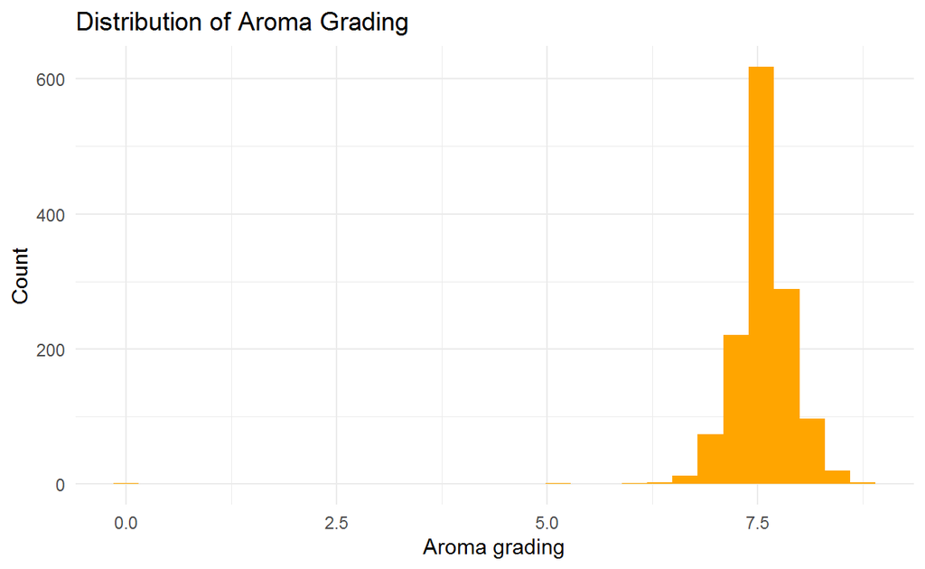

```r
ggplot(coffee_ratings) +
  geom_histogram(mapping = aes(aroma),fill="orange") +
  labs(x="Aroma grading",y="Count",title= "Distribution of Aroma Grading") +
  theme_minimal()
```

2. To look at any outliers present in the data, I used boxplot.

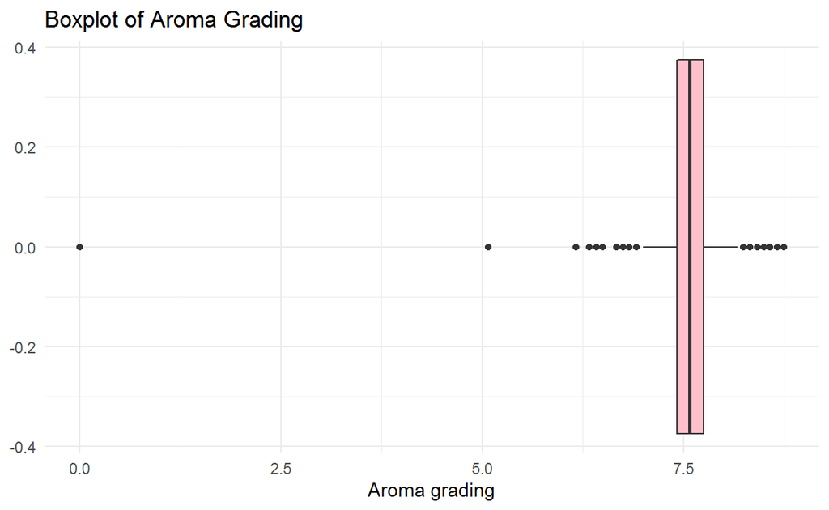

```r
ggplot(coffee_ratings) +
  geom_boxplot(aes(aroma),fill="Pink") +
  labs(x="Aroma grading",title= "Boxplot of Aroma Grading") +
  theme_minimal()
```

```r
coffee_ratings %>% filter(aroma < 6.25)
```

```
# A tibble: 3 x 43
  total_cup_points species owner country_of_orig~ farm_name lot_number
             <dbl> <chr>   <chr> <chr>            <chr>     <chr>
1             82.4 Arabica raca~ Colombia         <NA>      3-37-4434
2             76.3 Arabica juan~ Guatemala        conquist~ <NA>
3              0   Arabica bism~ Honduras         los hica~ 103
# ... with 37 more variables: mill <chr>, ico_number <chr>,
#   company <chr>, altitude <chr>, region <chr>, producer <chr>,
#   number_of_bags <dbl>, bag_weight <chr>, in_country_partner <chr>,
#   harvest_year <chr>, grading_date <chr>, owner_1 <chr>,
#   variety <chr>, processing_method <chr>, aroma <dbl>,
#   flavor <dbl>, aftertaste <dbl>, acidity <dbl>, body <dbl>,
#   balance <dbl>, uniformity <dbl>, clean_cup <dbl>,
#   sweetness <dbl>, cupper_points <dbl>, moisture <dbl>,
#   category_one_defects <dbl>, quakers <dbl>, color <chr>,
#   category_two_defects <dbl>, expiration <chr>,
#   certification_body <chr>, certification_address <chr>,
#   certification_contact <chr>, unit_of_measurement <chr>,
#   altitude_low_meters <dbl>, altitude_high_meters <dbl>,
#   altitude_mean_meters <dbl>
```

We consider these 3 as outliers as for bismarck castro’s arabica bean has 0.00 Total Cup Points and all 3 of them have category 2 defect along with low aroma grade.

To remove these outliers:

```r
coffee_ratings_without_aroma_outliers <- coffee_ratings %>% filter(aroma>6.25)
```

3. The shape of plot is Unimodal and we can see that the plot is Left skewed.
4. We can observe the mean and median of aroma grading before and after removing outliers:

*BEFORE*

```r
coffee_ratings %>% summarise(mean_aroma=mean(aroma),median_aroma=median(aroma))
```

```
# A tibble: 1 x 2
  mean_aroma median_aroma
       <dbl>        <dbl>
1       7.57         7.58
```

*AFTER*

```r
coffee_ratings_without_aroma_outliers %>% summarise(mean_aroma=mean(aroma),median_aroma=median(aroma))
```

```
# A tibble: 1 x 2
  mean_aroma median_aroma
       <dbl>        <dbl>
1       7.58         7.58
```

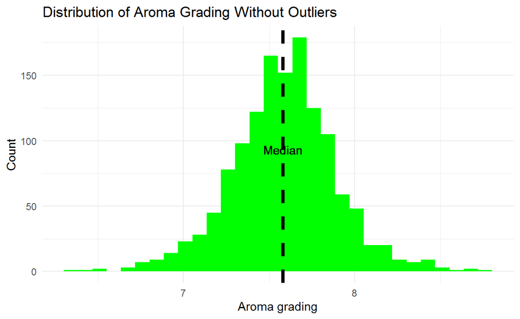

```r
ggplot(coffee_ratings_without_aroma_outliers) +
  geom_histogram(mapping = aes(aroma),fill="green") +
  geom_vline(mapping = aes(xintercept=median(aroma)),size=1.5,linetype="dashed") +
  geom_text(aes(x=median(aroma),y=100),label= "\nMedian", text=element_text(size=11)) +
  labs(x="Aroma grading",y="Count",title= "Distribution of Aroma Grading Without Outliers") +
  theme_minimal()
```

As we can see that just by removing the outliers the mean and median have came close and, we can get an almost symmetric plot which is close to normal distribution, therefore no further transformation is required.

*WITH OUTLIERS “MEAN, MEDIAN, STANDARD DEVIATION, IQR”*

```r
coffee_ratings %>% summarise(mean_aroma=mean(aroma),median_aroma=median(aroma),sd_aroma=sd(aroma),IQR_aroma=IQR(aroma))
```

```
# A tibble: 1 x 4
  mean_aroma median_aroma sd_aroma IQR_aroma
       <dbl>        <dbl>    <dbl>     <dbl>
1       7.57         7.58    0.378      0.33
```

*WITHOUT OUTLIERS “MEAN, MEDIAN, STANDARD DEVIATION, IQR”*

```r
coffee_ratings_without_aroma_outliers %>%
  summarise(
    mean_aroma=mean(aroma),median_aroma=median(aroma),sd_aroma=sd(aroma),IQR_aroma=IQR(aroma)
    )
```

```
# A tibble: 1 x 4
  mean_aroma median_aroma sd_aroma IQR_aroma
       <dbl>        <dbl>    <dbl>     <dbl>
1       7.58         7.58    0.306      0.33
```

6. From the above Quantitative Analysis we observe that, the data without outliers does not have much difference between “Mean” and “Median” thus we can use either of them, but if we use original data with outliers it would be better to use “Median” is more robust as compared to “Mean”.
7. From the above Quantitative Analysis we observe that, the data without outliers does not have much difference between “Standard Deviation” and “IQR” thus we can use either of them, but if we use original data with outliers it would be better to use “IQR” is more robust as compared to “Standard Deviation”.

## Selecting Variables

```r
coffee<- coffee_ratings %>% select(total_cup_points,
species,
country_of_origin,
number_of_bags,
variety,
processing_method,
flavor,
uniformity,
category_one_defects
)
```

### Continuous/Numerical variable: flavor

The score given for flavor account for the intensity, quality and complexity of its combined taste and aroma, experienced when the coffee is slurped into the mouth vigorously so as to involve the entire palate in the evaluation.

Using the glimpse function

```r
glimpse(coffee$country_of_origin)
```

```
 chr [1:1339] "Ethiopia" "Ethiopia" "Guatemala" "Ethiopia" ...
```

A quick summary of the statistics using skimr package

```r
skim(coffee$flavor)
```

Table 2: Data summary

| Name | coffee$flavor |
| --- | --- |
| Number of rows | 1339 |
| Number of columns | 1 |
| _______________________ |  |
| Column type frequency: |  |
| numeric | 1 |
| ________________________ |  |
| Group variables | None |

**Variable type: numeric**

| skim_variable | n_missing | complete_rate | mean | sd | p0 | p25 | p50 | p75 | p100 | hist |
| --- | --- | --- | --- | --- | --- | --- | --- | --- | --- | --- |
| data | 0 | 1 | 7.52 | 0.4 | 0 | 7.33 | 7.58 | 7.75 | 8.83 | ▁▁▁▁▇ |

There are no missing values for this variable and we can plot a histogram to check the distribution of values.

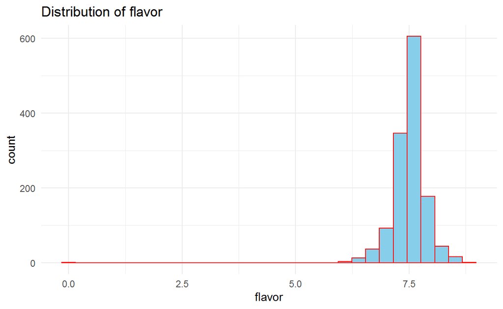

```r
ggplot(coffee)+
  geom_histogram(aes(flavor),color='red',fill='skyblue')+
  labs(title="Distribution of flavor")+
  theme_minimal()
```

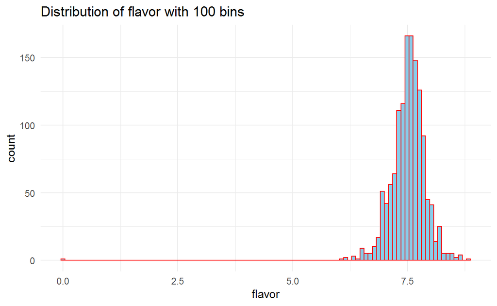

```r
ggplot(coffee)+
  geom_histogram(aes(flavor),bins=100,color='red',fill='skyblue')+
  labs(title="Distribution of flavor with 100 bins")+
  theme_minimal()
```

### Handling outliers

We can filter out the rows that have 0 values

```r
coffee %>% filter(flavor==0)
```

```
# A tibble: 1 x 9
  total_cup_points species country_of_origin number_of_bags variety
             <dbl> <chr>   <chr>                      <dbl> <chr>
1                0 Arabica Honduras                     275 Caturra
# ... with 4 more variables: processing_method <chr>, flavor <dbl>,
#   uniformity <dbl>, category_one_defects <dbl>
```

This row has 0 value for flavor and some other variables are also zero so we can assume it an entry error.We can remove this row by using

```r
coffee<-coffee[coffee$flavor!=0,]
```

Now again plotting the histogram after removing the outliers and increasing the number of bins to 35, we have an approximate symmetric distribution

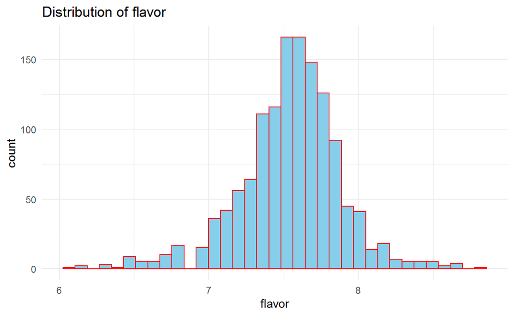

```r
ggplot(coffee)+
  geom_histogram(aes(flavor),bins=35,color='red',fill='skyblue')+
  labs(title="Distribution of flavor")+
  theme_minimal()
```

Since we already have a distribution that is pretty close to normal distribution, we don’t need to apply a transformation function such as log etc.

### Central tendency

Since flavor variable is not extremely skewed, mean is a very good measure of central tendency

```r
mean(coffee$flavor)
```

```
[1] 7.526046
```

### Plotting the mean

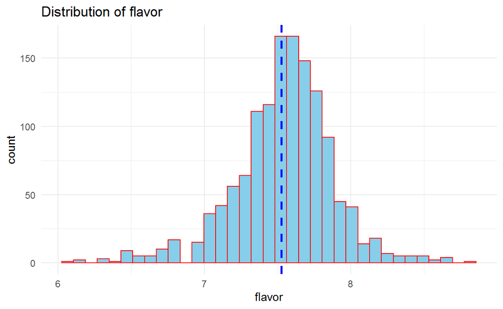

```r
p+geom_vline(aes(xintercept=mean(flavor)),
            color="blue", linetype="dashed", size=1)
```

### Spread using Standard Deviation

```r
sd(coffee$flavor)
```

```
[1] 0.3413824
```

We can see that most of our data values can fit within 3 standard deviations of the mean.

### For numeric variable I will be using aftertaste Grading of Coffee:

```r
skim(coffee_ratings$aftertaste)
```

Table 3: Data summary

| Name | coffee_ratings$aftertaste |
| --- | --- |
| Number of rows | 1339 |
| Number of columns | 1 |
| _______________________ |  |
| Column type frequency: |  |
| numeric | 1 |
| ________________________ |  |
| Group variables | None |

**Variable type: numeric**

| skim_variable | n_missing | complete_rate | mean | sd | p0 | p25 | p50 | p75 | p100 | hist |
| --- | --- | --- | --- | --- | --- | --- | --- | --- | --- | --- |
| data | 0 | 1 | 7.4 | 0.4 | 0 | 7.25 | 7.42 | 7.58 | 8.67 | ▁▁▁▁▇ |

### Distribution of aftertaste

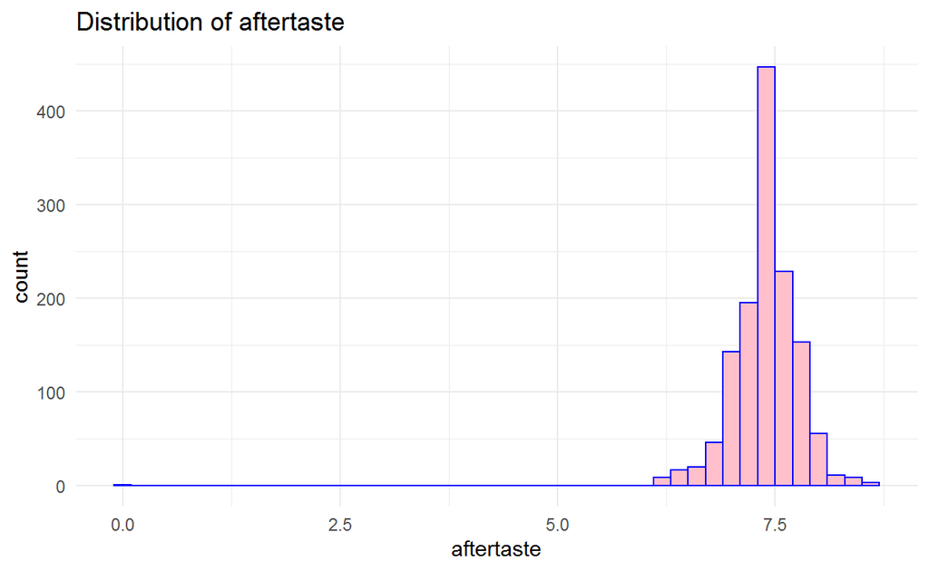

```r
ggplot(coffee_ratings)+
  geom_histogram(aes(aftertaste),color='blue',fill='pink', bins = 30, binwidth = 0.2)+
  labs(title="Distribution of aftertaste")+
  theme_minimal()
```

### To look at any outliers present in the data, I used boxplot.

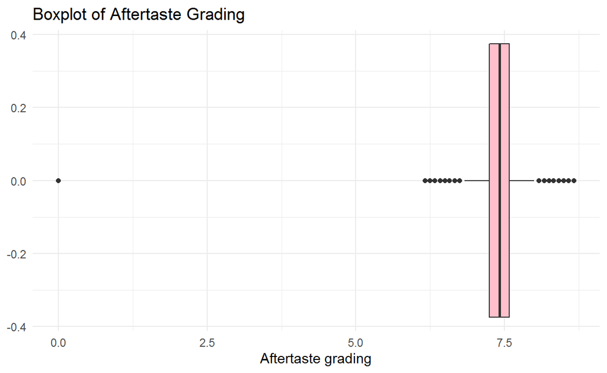

```r
ggplot(coffee_ratings) +
  geom_boxplot(aes(aftertaste),fill="Pink") +
  labs(x="Aftertaste grading",title= "Boxplot of Aftertaste Grading") +
  theme_minimal()
```

### This bit of the code creates a summary table that provides the min/max and inter-quartile range.

```r
coffee_ratings %>%
  summarise(Min = min(aftertaste),
            Max = max(aftertaste),
            Median = median(aftertaste),
            IQRange = IQR(aftertaste))
```

```
# A tibble: 1 x 4
    Min   Max Median IQRange
  <dbl> <dbl>  <dbl>   <dbl>
1     0  8.67   7.42    0.33
```

It is also possible to extract the values of the potential outliers based on the IQR criterion using the boxplot.stats()$out function:

```r
boxplot.stats(coffee_ratings$aftertaste)$out
```

```
 [1] 8.67 8.50 8.42 8.42 8.25 8.42 8.33 8.50 8.58 8.50 8.25 8.17 8.33
[14] 8.08 8.50 8.58 8.25 8.08 8.08 8.17 8.17 8.08 8.17 8.08 8.17 8.08
[27] 8.08 8.25 8.17 8.17 6.75 6.33 6.75 6.75 6.75 6.75 6.42 6.58 6.67
[40] 6.75 6.33 6.67 6.75 6.75 6.67 6.50 6.17 6.67 6.67 6.17 6.67 6.67
[53] 6.58 6.58 6.33 6.67 6.42 6.50 6.58 6.50 6.50 6.67 6.50 6.33 6.67
[66] 6.67 6.75 6.58 6.67 6.17 6.17 6.50 6.67 6.17 6.58 6.33 6.42 6.17
[79] 6.17 6.17 6.25 6.42 6.33 6.67 0.00 6.75 6.50
```

Extracting all the rows corresponding to these outliers:

```r
out <- boxplot.stats(coffee_ratings$aftertaste)$out
out_ind <- which(coffee_ratings$aftertaste %in% c(out))
coffee_ratings[out_ind,]
```

```
# A tibble: 87 x 43
   total_cup_points species owner     country_of_origin farm_name
              <dbl> <chr>   <chr>     <chr>             <chr>
 1             90.6 Arabica metad plc Ethiopia          "metad plc"
 2             89.9 Arabica metad plc Ethiopia          "metad plc"
 3             89.8 Arabica grounds ~ Guatemala         "san marcos b~
 4             89   Arabica yidnekac~ Ethiopia          "yidnekachew ~
 5             88.8 Arabica metad plc Ethiopia          "metad plc"
 6             88.8 Arabica ji-ae ahn Brazil             <NA>
 7             88.8 Arabica hugo val~ Peru               <NA>
 8             88.7 Arabica ethiopia~ Ethiopia          "aolme"
 9             88.4 Arabica ethiopia~ Ethiopia          "aolme"
10             88.2 Arabica diamond ~ Ethiopia          "tulla coffee~
# ... with 77 more rows, and 38 more variables: lot_number <chr>,
#   mill <chr>, ico_number <chr>, company <chr>, altitude <chr>,
#   region <chr>, producer <chr>, number_of_bags <dbl>,
#   bag_weight <chr>, in_country_partner <chr>, harvest_year <chr>,
#   grading_date <chr>, owner_1 <chr>, variety <chr>,
#   processing_method <chr>, aroma <dbl>, flavor <dbl>,
#   aftertaste <dbl>, acidity <dbl>, body <dbl>, balance <dbl>,
#   uniformity <dbl>, clean_cup <dbl>, sweetness <dbl>,
#   cupper_points <dbl>, moisture <dbl>, category_one_defects <dbl>,
#   quakers <dbl>, color <chr>, category_two_defects <dbl>,
#   expiration <chr>, certification_body <chr>,
#   certification_address <chr>, certification_contact <chr>,
#   unit_of_measurement <chr>, altitude_low_meters <dbl>,
#   altitude_high_meters <dbl>, altitude_mean_meters <dbl>
```

### Let’s add the mean of aftertaste to plot.

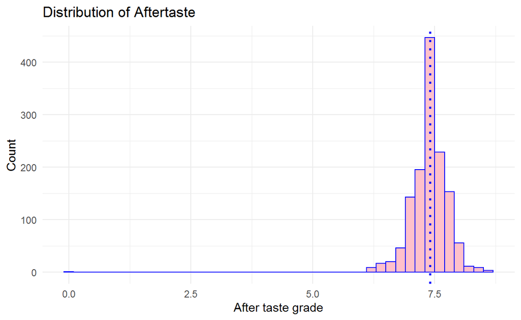

```r
coffee_ratings %>%
ggplot(aes(aftertaste)) +
    geom_histogram(binwidth = 0.2, color = "blue",fill = "pink", bins = 35) +
    geom_vline(xintercept = mean(coffee_ratings$aftertaste), lwd = 1, color= "blue", linetype="dotted"  ) +
    labs(title = "Distribution of Aftertaste",
         x = "After taste grade",
         y = "Count") +
  theme_minimal()
```

### For numeric variable I will be using Acidity Grading of Coffee:

1. To visualize the distribution of Acidity grading I will use histogram.

```r
skim(coffee_ratings$acidity)
```

Table 4: Data summary

| Name | coffee_ratings$acidity |
| --- | --- |
| Number of rows | 1339 |
| Number of columns | 1 |
| _______________________ |  |
| Column type frequency: |  |
| numeric | 1 |
| ________________________ |  |
| Group variables | None |

**Variable type: numeric**

| skim_variable | n_missing | complete_rate | mean | sd | p0 | p25 | p50 | p75 | p100 | hist |
| --- | --- | --- | --- | --- | --- | --- | --- | --- | --- | --- |
| data | 0 | 1 | 7.54 | 0.38 | 0 | 7.33 | 7.58 | 7.75 | 8.75 | ▁▁▁▁▇ |

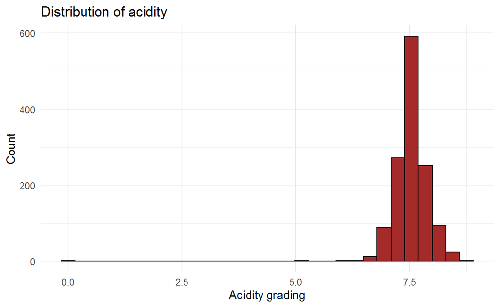

```r
ggplot(coffee_ratings) +
  geom_histogram(mapping = aes(acidity), color='black',fill="brown") +
  labs(x="Acidity grading",y="Count",title = "Distribution of acidity") +
  theme_minimal()
```

### To look at any outliers present in the data, I used boxplot.

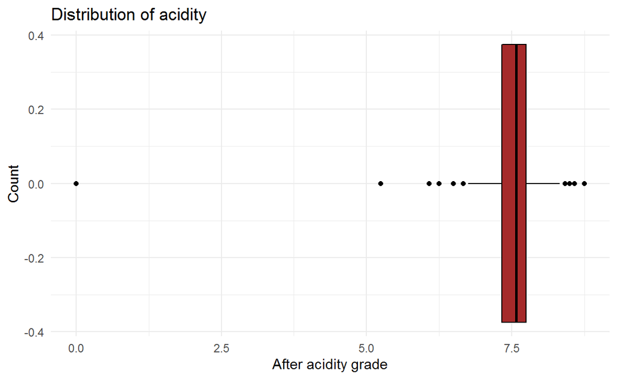

```r
ggplot(coffee_ratings,
       aes(acidity)) +
  geom_boxplot (bins = 10,color='black',fill='brown') +
    labs(title = "Distribution of acidity",
         x = "After acidity grade",
         y = "Count") +
  theme_minimal()
```

```r
coffee_ratings %>%
  summarise(Min = min(aftertaste),
            Max = max(aftertaste),
            Median = median(aftertaste),
            IQRange = IQR(aftertaste))
```

```
# A tibble: 1 x 4
    Min   Max Median IQRange
  <dbl> <dbl>  <dbl>   <dbl>
1     0  8.67   7.42    0.33
```

4. We can also extract the values of outliers by using the boxplot.ststs()out function

```r
boxplot.stats(coffee_ratings$acidity)$out
```

```
 [1] 8.75 8.58 8.42 8.42 8.50 8.50 8.50 8.42 8.42 8.50 8.50 8.42 8.50
[14] 8.50 8.42 5.25 6.67 6.67 6.08 6.67 6.67 6.50 6.67 6.25 0.00
```

```r
out <- boxplot.stats(coffee_ratings$acidity)$out
out_ind <- which(coffee_ratings$acidity %in% c(out))
coffee_ratings[out_ind,]
```

```
# A tibble: 25 x 43
   total_cup_points species owner     country_of_origin farm_name
              <dbl> <chr>   <chr>     <chr>             <chr>
 1             90.6 Arabica metad plc Ethiopia          "metad plc"
 2             89.9 Arabica metad plc Ethiopia          "metad plc"
 3             89.8 Arabica grounds ~ Guatemala         "san marcos b~
 4             89   Arabica yidnekac~ Ethiopia          "yidnekachew ~
 5             88.8 Arabica metad plc Ethiopia          "metad plc"
 6             88.8 Arabica ji-ae ahn Brazil             <NA>
 7             88.8 Arabica hugo val~ Peru               <NA>
 8             88.7 Arabica ethiopia~ Ethiopia          "aolme"
 9             88.4 Arabica ethiopia~ Ethiopia          "aolme"
10             88.2 Arabica diamond ~ Ethiopia          "tulla coffee~
# ... with 15 more rows, and 38 more variables: lot_number <chr>,
#   mill <chr>, ico_number <chr>, company <chr>, altitude <chr>,
#   region <chr>, producer <chr>, number_of_bags <dbl>,
#   bag_weight <chr>, in_country_partner <chr>, harvest_year <chr>,
#   grading_date <chr>, owner_1 <chr>, variety <chr>,
#   processing_method <chr>, aroma <dbl>, flavor <dbl>,
#   aftertaste <dbl>, acidity <dbl>, body <dbl>, balance <dbl>,
#   uniformity <dbl>, clean_cup <dbl>, sweetness <dbl>,
#   cupper_points <dbl>, moisture <dbl>, category_one_defects <dbl>,
#   quakers <dbl>, color <chr>, category_two_defects <dbl>,
#   expiration <chr>, certification_body <chr>,
#   certification_address <chr>, certification_contact <chr>,
#   unit_of_measurement <chr>, altitude_low_meters <dbl>,
#   altitude_high_meters <dbl>, altitude_mean_meters <dbl>
```

### Now I am adding Mean

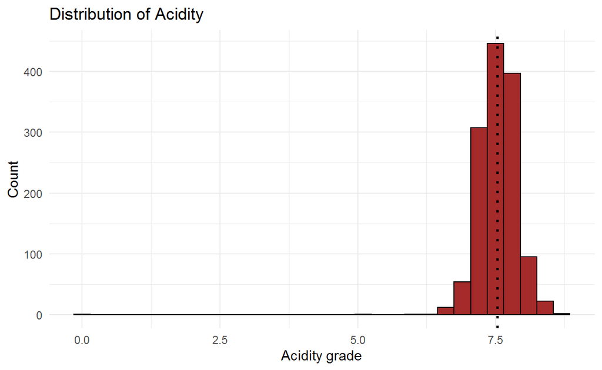

```r
coffee_ratings %>%
ggplot(aes(acidity)) +
    geom_histogram(binwidth = 0.30, color = "black",fill = "brown", bins = 35) +
    geom_vline(xintercept = mean(coffee_ratings$acidity), lwd = 1, color= "black", linetype="dotted"  ) +
    labs(title = "Distribution of Acidity",
         x = "Acidity grade",
         y = "Count") +
  theme_minimal()
```

1. For first univariate analysis I am using body variable

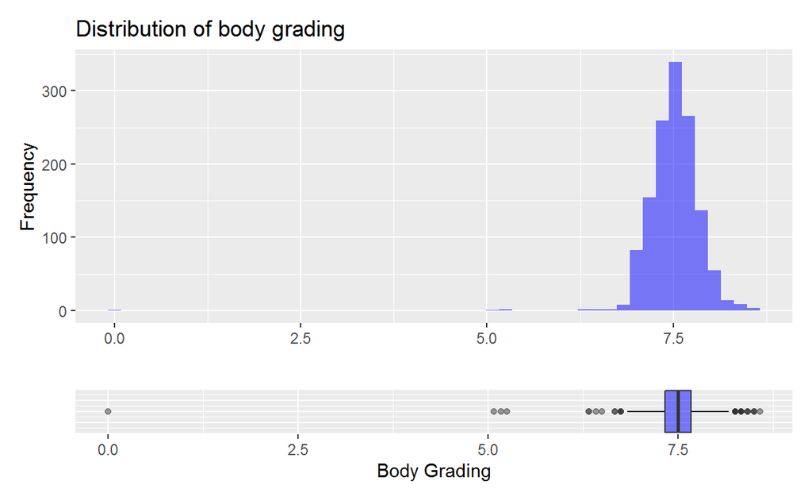

```r
plt1 <- ggplot(data = coffee_ratings,
       aes(body))+
  geom_histogram(bins=50,fill="blue",alpha=0.5,show.legend = FALSE) +ylab("Frequency") +xlab("")+
  labs(title = "Distribution of body grading")

plt2 <- ggplot(coffee_ratings,aes(body),color =  "blue")+
  geom_boxplot(fill  ="blue",alpha = 0.5) +  xlab("Body Grading") +
  theme(axis.text.y=element_blank(),
        axis.ticks.y=element_blank())

plt1 + plt2 + plot_layout(nrow = 2, heights = c(6, 1))
```

2. As can be seen from the box plot there are outliers below 6 and now we will filter out outliers

```r
coffee_ratings %>% filter(body < 6)
```

```
# A tibble: 4 x 43
  total_cup_points species owner country_of_orig~ farm_name lot_number
             <dbl> <chr>   <chr> <chr>            <chr>     <chr>
1             81.7 Arabica raca~ Colombia         <NA>      3-37-1367
2              0   Arabica bism~ Honduras         los hica~ 103
3             78.8 Robusta luis~ Ecuador          robustasa Lavado 1
4             78.1 Robusta luis~ Ecuador          robustasa Lavado 3
# ... with 37 more variables: mill <chr>, ico_number <chr>,
#   company <chr>, altitude <chr>, region <chr>, producer <chr>,
#   number_of_bags <dbl>, bag_weight <chr>, in_country_partner <chr>,
#   harvest_year <chr>, grading_date <chr>, owner_1 <chr>,
#   variety <chr>, processing_method <chr>, aroma <dbl>,
#   flavor <dbl>, aftertaste <dbl>, acidity <dbl>, body <dbl>,
#   balance <dbl>, uniformity <dbl>, clean_cup <dbl>,
#   sweetness <dbl>, cupper_points <dbl>, moisture <dbl>,
#   category_one_defects <dbl>, quakers <dbl>, color <chr>,
#   category_two_defects <dbl>, expiration <chr>,
#   certification_body <chr>, certification_address <chr>,
#   certification_contact <chr>, unit_of_measurement <chr>,
#   altitude_low_meters <dbl>, altitude_high_meters <dbl>,
#   altitude_mean_meters <dbl>
```

We will consider these 4 as outliers as bismark castro has zero total cup points and other three have very low body grade points.

3. To remove the outliers in body variable:

```r
coffee_ratings_Body_outliers_removed <- coffee_ratings %>% filter(body > 6)
```

4. Plotting the graph after removing outliers

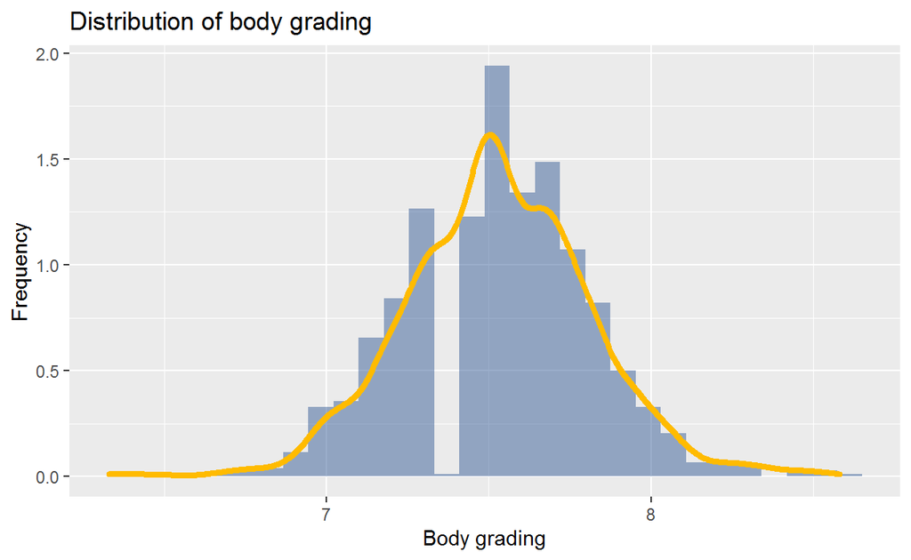

```r
 coffee_ratings_Body_outliers_removed %>% ggplot(aes(body)) +
  geom_histogram(aes(y=..density..),fill="#375E97",alpha=0.5) +
  geom_density(col="#FFBB00",size=1.5) +
  labs(x="Body grading",y="Frequency",title = "Distribution of body grading")
```

> As can be seen from the graph that it has one peak so the plot is unimodal and no visible skewness is there which indicates that the graph is somewhat bell curved and also simialr to normal distribution.
5. Checking change in mean and median before and after removing outliers

### BEFORE

```r
coffee_ratings %>%
    summarize(variable = "body",mean_body = mean(body), median_body = median(body)) %>%
    pander()
```

| variable | mean_body | median_body |
| --- | --- | --- |
| body | 7.517 | 7.5 |

### AFTER

```r
coffee_ratings_Body_outliers_removed %>%
    summarize(variable = "body",mean_body = mean(body), median_body = median(body)) %>%
    pander()
```

| variable | mean_body | median_body |
| --- | --- | --- |
| body | 7.528 | 7.5 |

6. Now we will check change in 20%,40%,60% and 80% quantiles before and after removing outliers

### Before

```r
coffee_ratings %>%
    summarize(variable = "body",
              sd_body = sd(body),
              q0.2 = quantile(body, 0.2),
              q0.4 = quantile(body, 0.4),
              q0.6 = quantile(body, 0.6),
              q0.8 = quantile(body, 0.8),
              IQR_body = IQR(body)) %>%
    pander
```

| variable | sd_body | q0.2 | q0.4 | q0.6 | q0.8 | IQR_body |
| --- | --- | --- | --- | --- | --- | --- |
| body | 0.3701 | 7.33 | 7.5 | 7.58 | 7.75 | 0.34 |

### After

```r
coffee_ratings_Body_outliers_removed %>%
    summarize(variable = "body",
              sd_body = sd(body),
              q0.2 = quantile(body, 0.2),
              q0.4 = quantile(body, 0.4),
              q0.6 = quantile(body, 0.6),
              q0.8 = quantile(body, 0.8),
              IQR_body = IQR(body)) %>%
    pander
```

| variable | sd_body | q0.2 | q0.4 | q0.6 | q0.8 | IQR_body |
| --- | --- | --- | --- | --- | --- | --- |
| body | 0.2871 | 7.33 | 7.5 | 7.58 | 7.75 | 0.34 |

7. From the above quantitative analysis we can see that after removing outliers the standard deviation of the variable body have decreased but there is no change in different quantile and simultaneously in IQR.

### For categorical variable, I will be using Owner:

```r
coffee_ratings_owner <- coffee_ratings %>%
  filter(total_cup_points != 0) %>%
  mutate(owner = str_replace_all(owner, "[^a-zA-Z0-9 ]", ""),
         owner = str_trim(owner))
coffee_ratings_clean_owner <- coffee_ratings_owner %>% drop_na(owner)
coffeee_ratings_clean_owner <- coffee_ratings_clean_owner %>% group_by(owner) %>% count(owner,sort = TRUE)
coffee_ratings_clean_owner <- head(coffeee_ratings_clean_owner,10)
```

1. To visualize the distribution of counts for this variable, a bar chart would seem appropriate.

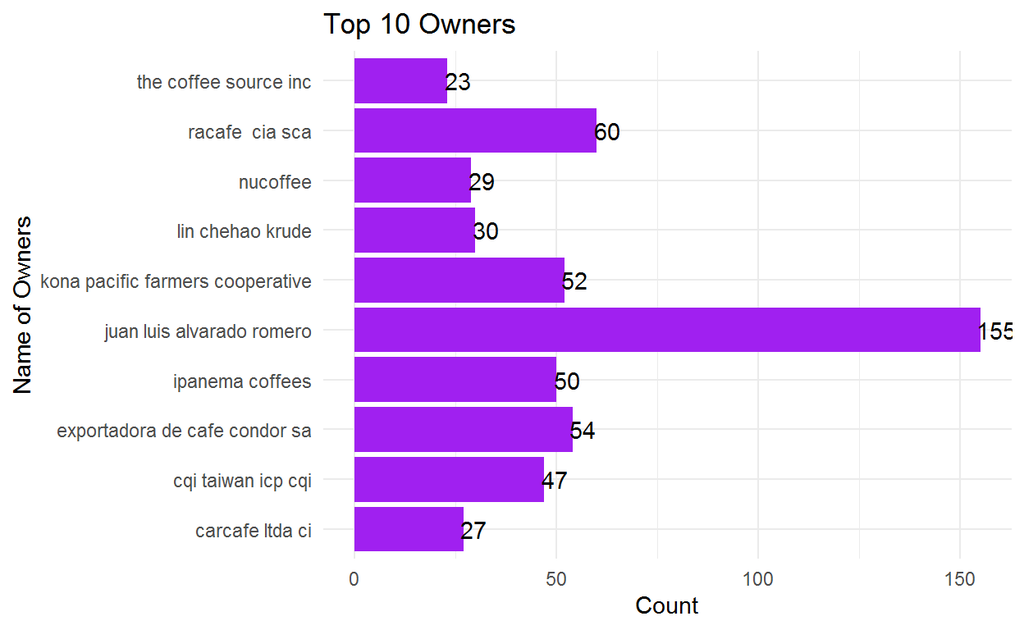

```r
ggplot(coffee_ratings_clean_owner,aes(owner,n)) +
  geom_bar(stat = 'identity',fill="purple") +
  geom_text(aes(label=n,hjust=0.1)) +
  labs(x="Name of Owners",y="Count",title= "Top 10 Owners") +
  theme_minimal() +
  coord_flip()
```

2. To visualize the distribution of proportions for this variable, I would use another bar chart.

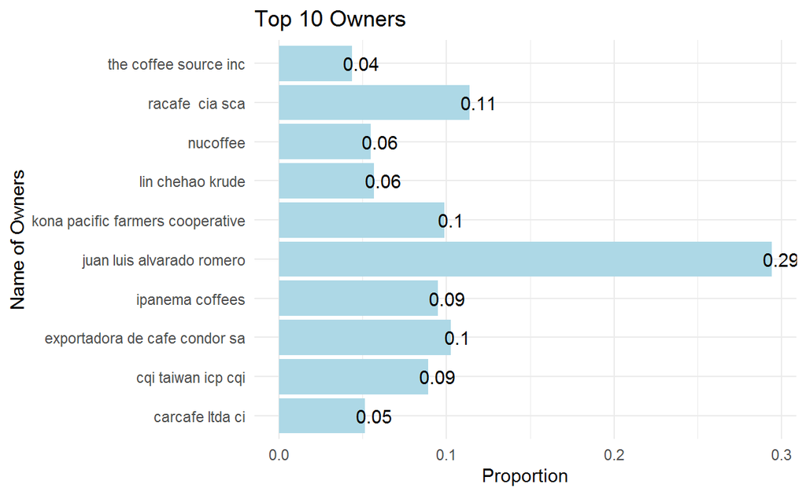

```r
sum <- sum(coffee_ratings_clean_owner$n)
coffee_ratings_clean_owner <-coffee_ratings_clean_owner %>% mutate(x=n/sum)
ggplot(coffee_ratings_clean_owner,aes(owner,x)) +
  geom_bar(stat='identity',fill="lightblue") +
  geom_text(aes(label=round(x,2),hjust=0.25)) +
  labs(x="Name of Owners",y="Proportion",title= "Top 10 Owners") +
  theme_minimal() +
  coord_flip()
```

```r
unique(coffee_ratings_clean_owner$owner)
```

```
 [1] "juan luis alvarado romero"
 [2] "racafe  cia sca"
 [3] "exportadora de cafe condor sa"
 [4] "kona pacific farmers cooperative"
 [5] "ipanema coffees"
 [6] "cqi taiwan icp cqi"
 [7] "lin chehao krude"
 [8] "nucoffee"
 [9] "carcafe ltda ci"
[10] "the coffee source inc"
```

### First variable I am using for univariate analysis is country_of_origin which is the country where the coffee is from.

### Categorical variable: country_of_origin

Using the glimpse function

```r
glimpse(coffee$country_of_origin)
```

```
 chr [1:1338] "Ethiopia" "Ethiopia" "Guatemala" "Ethiopia" ...
```

### Bar chart

Mexico is the country where most of the coffee comes from.

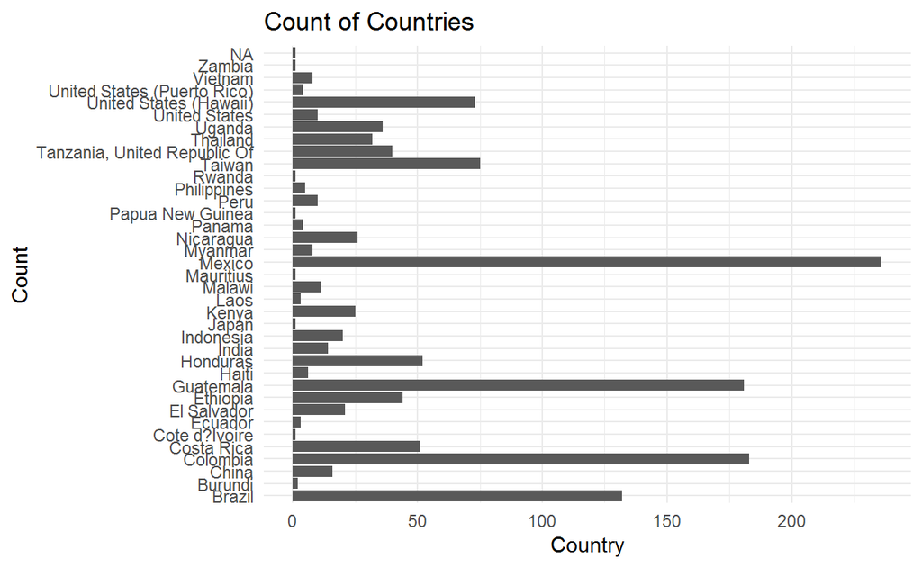

```r
ggplot(coffee)+
  geom_bar(aes(country_of_origin))+
  labs(title="Count of Countries",x="Count",y="Country")+
  coord_flip()+
  theme_minimal()
```

### Proportion table

I have shown the distribution of countries in this variable by proportion which also confirms that Mexico indeed has the biggest proportion out of all countries, followed by Colombia and Guatemala.

```r
sort(round(proportions(table(coffee$country_of_origin)),2),decreasing=TRUE)
```

```
                      Mexico                     Colombia
                        0.18                         0.14
                   Guatemala                       Brazil
                        0.14                         0.10
                      Taiwan       United States (Hawaii)
                        0.06                         0.05
                  Costa Rica                     Honduras
                        0.04                         0.04
                    Ethiopia Tanzania, United Republic Of
                        0.03                         0.03
                      Uganda                  El Salvador
                        0.03                         0.02
                       Kenya                    Nicaragua
                        0.02                         0.02
                    Thailand                        China
                        0.02                         0.01
                       India                    Indonesia
                        0.01                         0.01
                      Malawi                      Myanmar
                        0.01                         0.01
                        Peru                United States
                        0.01                         0.01
                     Vietnam                      Burundi
                        0.01                         0.00
               Cote d?Ivoire                      Ecuador
                        0.00                         0.00
                       Haiti                        Japan
                        0.00                         0.00
                        Laos                    Mauritius
                        0.00                         0.00
                      Panama             Papua New Guinea
                        0.00                         0.00
                 Philippines                       Rwanda
                        0.00                         0.00
 United States (Puerto Rico)                       Zambia
                        0.00                         0.00
```

No unusual behavior has been detected in this variable and it works as expected.

We can use the skimr package to check for empty values and we can see that are 36 unique countries and only one NA value.

```r
skim(coffee$country_of_origin)
```

Table 5: Data summary

| Name | coffee$country_of_origin |
| --- | --- |
| Number of rows | 1338 |
| Number of columns | 1 |
| _______________________ |  |
| Column type frequency: |  |
| character | 1 |
| ________________________ |  |
| Group variables | None |

**Variable type: character**

| skim_variable | n_missing | complete_rate | min | max | empty | n_unique | whitespace |
| --- | --- | --- | --- | --- | --- | --- | --- |
| data | 1 | 1 | 4 | 28 | 0 | 36 | 0 |

### For categorical variable, I will be using Producers:

### Top 10 Producers of coffee

```r
glimpse(coffee_ratings$producer)
```

```
 chr [1:1339] "METAD PLC" "METAD PLC" NA ...
```

Frequency table for Producers

```r
coffee_producers<- as.data.frame(sort(table(grep('^[A-Za-z ]+$', coffee_ratings$producer, value = TRUE))),decreasing = TRUE)
colnames(coffee_producers)<-c('producers', 'count')
tibble(coffee_producers)
```

```
# A tibble: 429 x 2
   producers                   count
   <fct>                       <int>
 1 Acacia Hills Ltd                1
 2 ADRIANA TORRES RICO QUEVEDO     1
 3 AGRICOLA MONTE VERDE            1
 4 AGROINDUSTRIAS CAFETALERAS      1
 5 Agrotello Coop                  1
 6 ALBERTA TEODORO ANALCO          1
 7 ALFREDO MOISES CEJA             1
 8 Alvaro Resende Aguiar           1
 9 AMADOR HERNANDEZ DIONICIO       1
10 AMANCIO DEL VALLE CARRILLO      1
# ... with 419 more rows
```

1. To visualize the distribution of counts for this variable, a bar chart would seem appropriate.

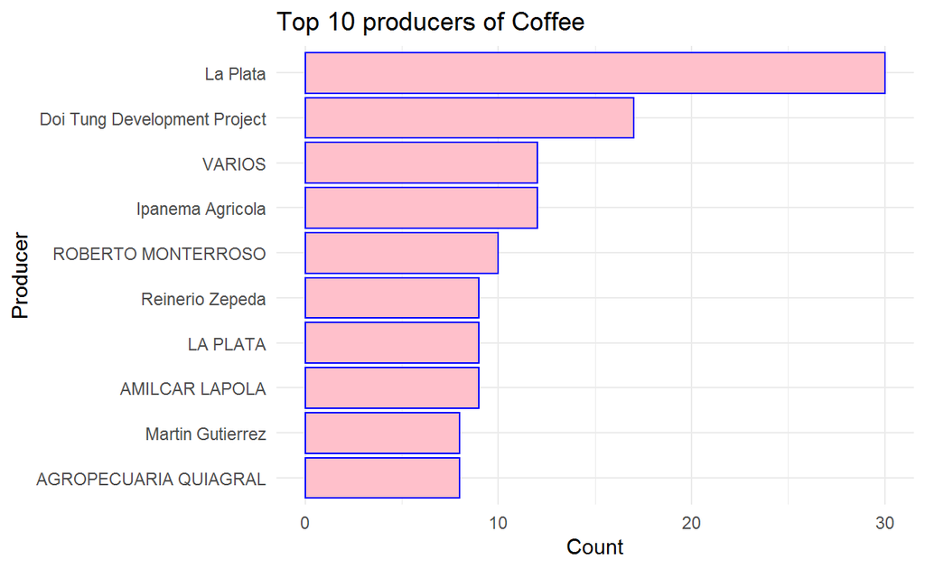

```r
top_producers<-as.data.frame(tail(coffee_producers,10))

ggplot(data = top_producers, mapping = aes(producers,count))+
  geom_bar(stat = 'identity',fill='pink',color = 'blue')+
  labs(title = "Top 10 producers of Coffee")+
  xlab("Producer")+
  ylab("Count")+
  coord_flip()+
  theme_minimal()
```

```r
top_producers<-as.data.frame(tail(coffee_producers,10))
top_producers
```

```
                       producers count
420        AGROPECUARIA QUIAGRAL     8
421             Martin Gutierrez     8
422               AMILCAR LAPOLA     9
423                     LA PLATA     9
424              Reinerio Zepeda     9
425           ROBERTO MONTERROSO    10
426             Ipanema Agricola    12
427                       VARIOS    12
428 Doi Tung Development Project    17
429                     La Plata    30
```

5. To visualize the distribution of proportions for this variable, I would use another bar chart.

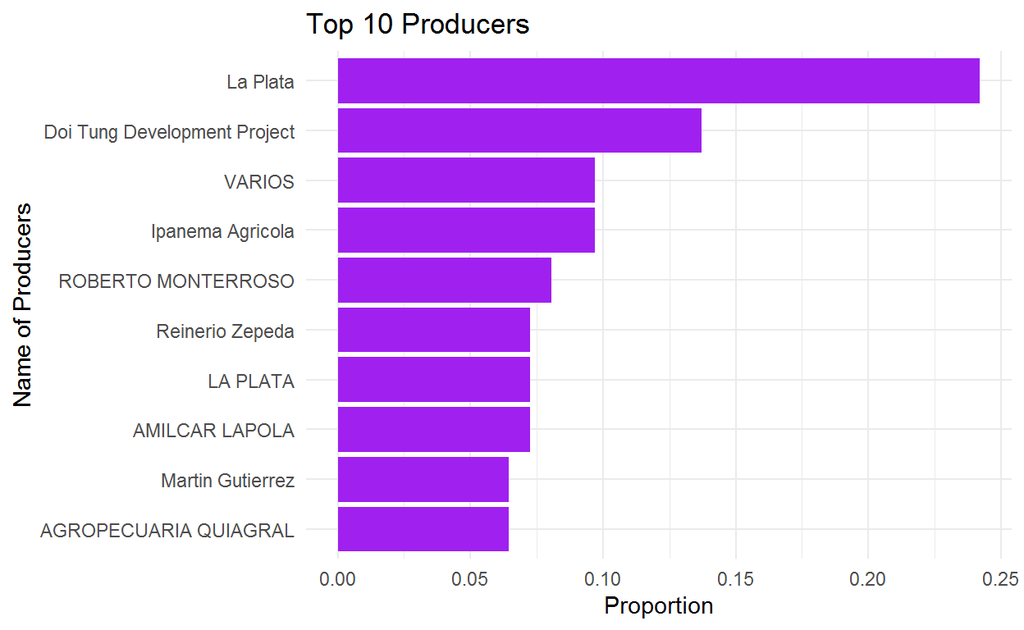

```r
sum <- sum(top_producers$count)

top_producers <-top_producers %>% mutate(x=count/sum)
ggplot(top_producers,aes(producers,x)) +
  geom_bar(stat='identity',fill="purple") +
  labs(x="Name of Producers",y="Proportion",title= "Top 10 Producers") +
  theme_minimal() +
  coord_flip()
```

### For categorical variable, I will be using Variety:

```r
unique(coffee_ratings$variety)
```

```
 [1] NA                      "Other"
 [3] "Bourbon"               "Catimor"
 [5] "Ethiopian Yirgacheffe" "Caturra"
 [7] "SL14"                  "Sumatra"
 [9] "SL34"                  "Hawaiian Kona"
[11] "Yellow Bourbon"        "SL28"
[13] "Gesha"                 "Catuai"
[15] "Pacamara"              "Typica"
[17] "Sumatra Lintong"       "Mundo Novo"
[19] "Java"                  "Peaberry"
[21] "Pacas"                 "Mandheling"
[23] "Ruiru 11"              "Arusha"
[25] "Ethiopian Heirlooms"   "Moka Peaberry"
[27] "Sulawesi"              "Blue Mountain"
[29] "Marigojipe"            "Pache Comun"
```

```r
tab<- data.frame(table(coffee_ratings$variety))
colnames(tab)<- c('variety','count')
tab
```

```
                 variety count
1                 Arusha     6
2          Blue Mountain     2
3                Bourbon   226
4                Catimor    20
5                 Catuai    74
6                Caturra   256
7    Ethiopian Heirlooms     1
8  Ethiopian Yirgacheffe     2
9                  Gesha    12
10         Hawaiian Kona    44
11                  Java     2
12            Mandheling     3
13            Marigojipe     1
14         Moka Peaberry     1
15            Mundo Novo    33
16                 Other   110
17              Pacamara     8
18                 Pacas    13
19           Pache Comun     1
20              Peaberry     5
21              Ruiru 11     2
22                  SL14    17
23                  SL28    15
24                  SL34     8
25              Sulawesi     1
26               Sumatra     3
27       Sumatra Lintong     1
28                Typica   211
29        Yellow Bourbon    35
```

1. To visualize the distribution of counts for this variable, a bar chart would seem appropriate.

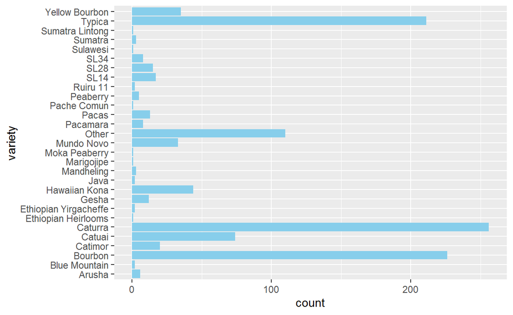

```r
ggplot(data = drop_na(tab),mapping = aes(variety,count))+
  geom_bar(fill = 'skyblue', stat = 'identity')+
  coord_flip()
```

1. For this we are using processing method that is used by companies to process coffee beans.

```r
unique(coffee_ratings$processing_method)
```

```
[1] "Washed / Wet"              NA
[3] "Natural / Dry"             "Pulped natural / honey"
[5] "Semi-washed / Semi-pulped" "Other"
```

2. Now We will plot these using bar graph to understand the frequency in each category

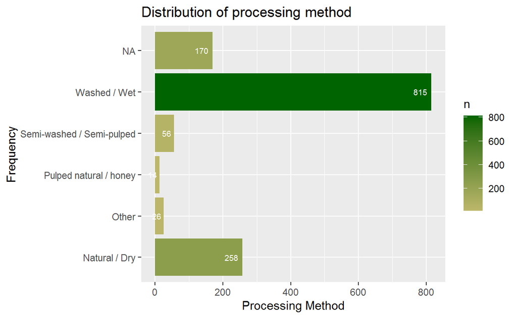

```r
processing_method_table<-coffee_ratings %>% count(processing_method = factor(processing_method))

ggplot(processing_method_table,aes(x = processing_method,y = n, fill = n))+
  geom_bar(stat="identity")+
  labs(title="Count of Countries",x="Count",y="Country")+
  coord_flip()+geom_text(aes(label = n),size = 2.5,color = "white",hjust = 1.3)+
 scale_fill_gradient(low="darkkhaki", high="darkgreen")+
  labs(x ="Frequency" , y = "Processing Method",title = "Distribution of processing method")
```

3. Now we will be checking the frequency and relative frequency of each category in processing method.

```r
coffee_ratings %>%
    group_by(processing_method) %>%
    summarize(frequency = n()) %>%
    arrange(desc(frequency)) %>%
    mutate(relative_frequency = frequency/sum(frequency)) %>%
    pander
```

| processing_method | frequency | relative_frequency |
| --- | --- | --- |
| Washed / Wet | 815 | 0.6087 |
| Natural / Dry | 258 | 0.1927 |
| NA | 170 | 0.127 |
| Semi-washed / Semi-pulped | 56 | 0.04182 |
| Other | 26 | 0.01942 |
| Pulped natural / honey | 14 | 0.01046 |

4. Removing NA’s

```r
coffee_ratings_no_missing <- coffee_ratings %>% drop_na(processing_method)
```

5. Visualizing the proportion of processing methods

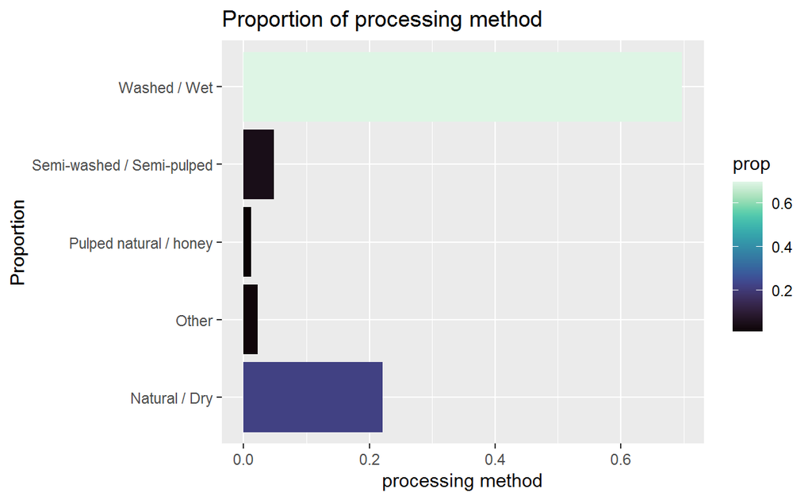

```r
ggplot(coffee_ratings_no_missing) +
  geom_bar(aes(x= processing_method,y=..prop..,group=1,fill = ..prop..)) +
  coord_flip()+
  scale_fill_viridis(option = "mako")+
  labs(x="Proportion",y="processing method",title= "Proportion of processing method")
```

> washed/wet method of processing coffee beans is used almost 70% of times whereas Pulped natural/honey method of processing is least used.

# For Bivariate Analysis

### For 2 numerical variables pair, I will use Moisture grade and Balance grade:

1. Scatter plot with smoothing line to visualize the relationship between these two variables. (4 marks)

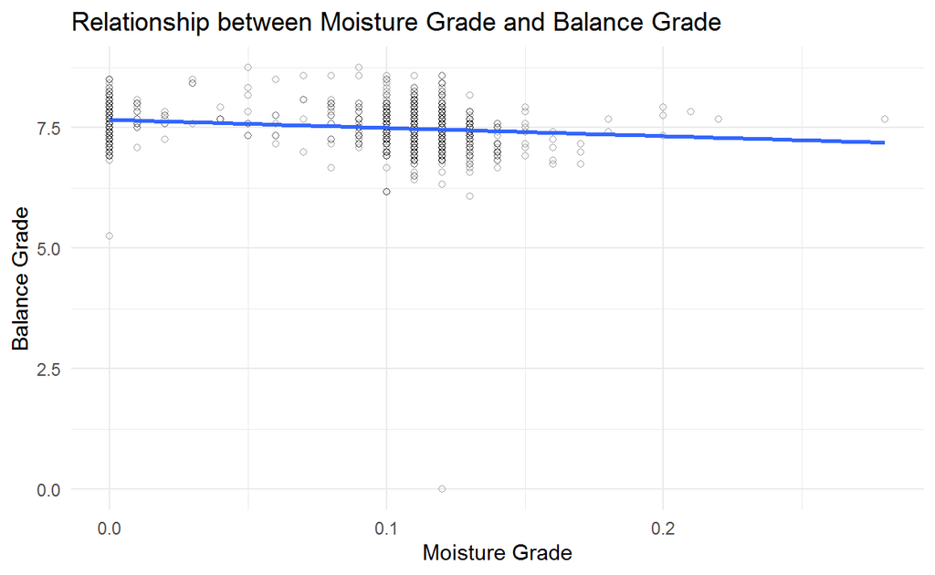

```r
ggplot(coffee_ratings,aes(moisture,balance)) +
  geom_point(shape=21,alpha= 1/3) +
  geom_smooth(method='lm',se=FALSE) +
  labs(x="Moisture Grade",y="Balance Grade",title= "Relationship between Moisture Grade and Balance Grade") +
  theme_minimal()
```

2. There seems to be a negative, linear relationship between Moisture Grade and Balance Grade,but it appears to be somewhat a weak relationship. I would have expected a similar correlation based on general expectations of moisture degrading the balace of seed.

The correlation coefficient is:

```r
cor(coffee_ratings$moisture,coffee_ratings$balance)
```

```
[1] -0.1998433
```

The value of correlation coefficient is on the weaker side and it confirms what we see on the plot. Although weak the relationship does show that, on average, that as moisture grade increase we would expect a decrease in balance grade.

### Two numerical variables: Uniformity and total_cup_points

Creating a scatter plot between uniformity and the total cup points.total_cup_points variable contains a a rating out of 100 for the coffee beans.

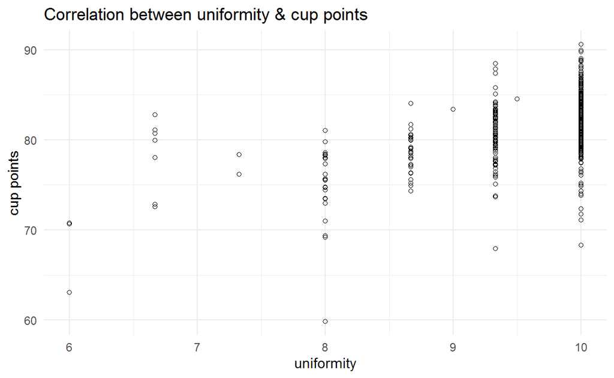

```r
ggplot(coffee,aes(uniformity,total_cup_points))+
  geom_point(shape=21)+
  labs(title="Correlation between uniformity & cup points",y="cup points")+
  theme_minimal()
```

We can see that as uniformity increases, total cup points also increase.

Adding a best fit line to the scatter plot, it appears that uniformity has a linear positive relationship with total cup points, meaning the higher the uniformity of flavor, the higher the coffee is rated out of a 100.

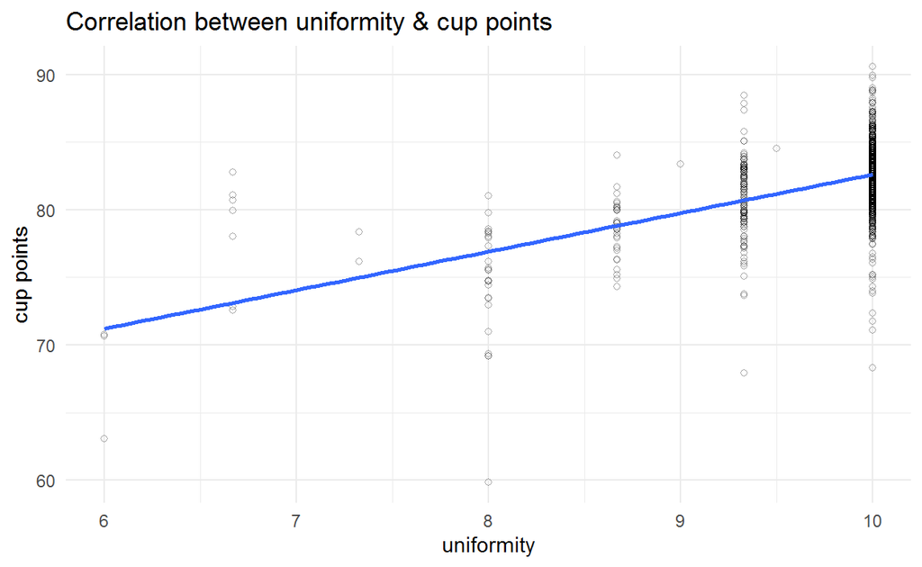

```r
ggplot(coffee,aes(uniformity,total_cup_points))+
  geom_point(shape=21,alpha=1/3)+
  geom_smooth(method='lm', se=FALSE)+
  labs(title="Correlation between uniformity & cup points",y="cup points")+
  theme_minimal()
```

We can calculate the correlation coefficient to know the strength of this relationship

```r
cor(coffee$uniformity,coffee$total_cup_points)
```

```
[1] 0.5147862
```

It is a fairly strong relationship with 0.5 correlation coefficient.

### For 2 numerical variables pair, I will use Altitude_mean_meters and total_cup_points:

1. Scatter plot with smoothing line to visualize the relationship between these two variables.

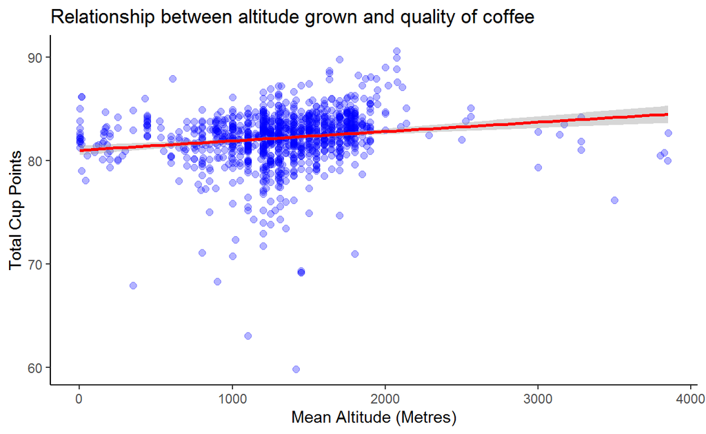

```r
coffee_ratings %>%
  filter(altitude_mean_meters < 4000, total_cup_points > 0) %>%
  ggplot(aes(x = altitude_mean_meters, y = total_cup_points)) +
  theme_classic()+
  geom_point(colour = "blue", alpha = 0.3, size = 2) +
  geom_smooth(method = "lm",color="red") +
  labs(x = "Mean Altitude (Metres)", y = "Total Cup Points", title = "Relationship between altitude grown and quality of coffee")
```

2. There seems to be a positive, linear relationship between plotted variables,but it appears to be somewhat a weak relationship.

The correlation coefficient is:

```r
cor(coffee_ratings$altitude_mean_meters< 4000,coffee_ratings$total_cup_points,use="na.or.complete")
```

```
[1] 0.01904065
```

# For Bivariate Analysis

### For 2 numerical variables pair, I am using Flavor and Aroma

1. Scatter plot with smoothing line to visualize the relationship between these two variables. (4 marks)

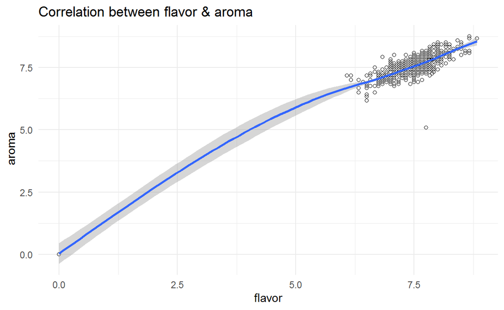

```r
ggplot(coffee_ratings,aes(flavor,aroma))+
  geom_point(shape=21)+
  geom_smooth()+
  labs(title="Correlation between flavor & aroma",y=" aroma")+
  theme_minimal()
```

2. There is a positive and linear relationship between Flavor and Aroma.

The correlation coefficient is:

```r
cor(coffee_ratings$flavor,coffee_ratings$aroma)
```

```
[1] 0.8132595
```

The value of correlation coefficient is on the stronger side and we can see on the plot.

### For our bivariate analysis of two numerical variables:

We will be using cupper points grade and total cup points. Cupper points indicate 0-10 grade on tasting by producers and buyers around the world to check the quality of a batch of coffee and total cup points indicate 0-100 rating on the basis of different factors.

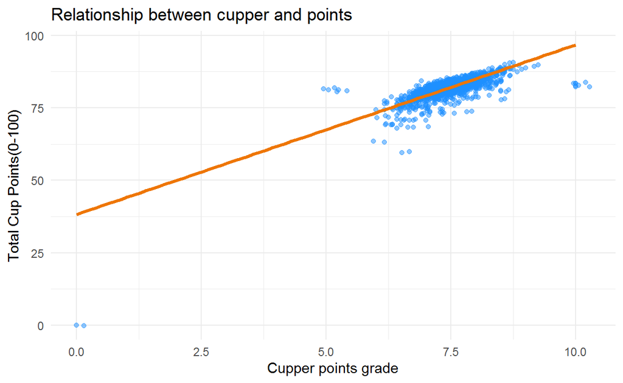

```r
coffee_ratings %>%
    ggplot(aes(cupper_points, total_cup_points)) +
    geom_point(color = "dodgerblue", alpha = .5) +
    theme_minimal() +
    labs(x="Cupper points grade",y="Total Cup Points(0-100)",title= "Relationship between cupper and points ") +
  geom_jitter(height=0.5, width=0.3,color = "dodgerblue", alpha = .5)+
    geom_smooth(method = "lm", se = F,color = "darkorange2", size = 1.2)
```

> As can be seen there is a positive and linear relationship between two variables.
3. We can now check the pearson correlation coefficient:

```r
coffee_ratings %>%
    select(total_cup_points, cupper_points) %>%
    cor %>%
    pander
```

|  | total_cup_points | cupper_points |
| --- | --- | --- |
| **total_cup_points** | 1 | 0.7902 |
| **cupper_points** | 0.7902 | 1 |

> As can be seen by the coefficient there is fairly strong positive correlation.

### For 1 Numerical and 1 Categorical variable pair, I will use Color and Cupper Points:

1. To visualize the relationship between these two variables we will use Boxplot.

```r
coffee_ratings_clean_color <- coffee_ratings %>%
  drop_na(color)
```

```r
coffee_ratings_clean_color_median <- coffee_ratings_clean_color %>%
  group_by(color) %>%
  summarise(median=median(cupper_points)) %>%
  ungroup()
```

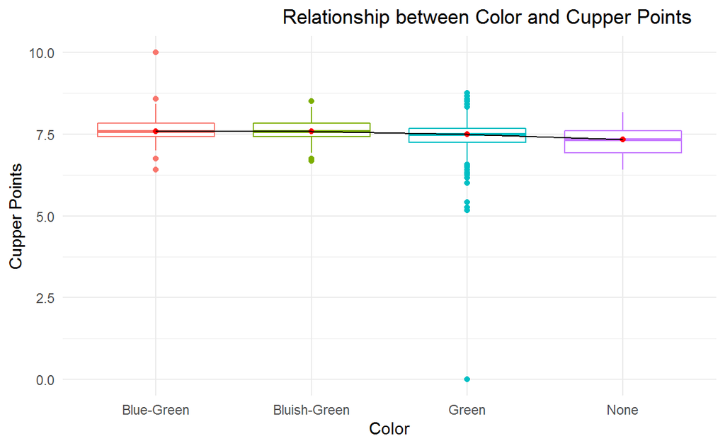

```r
ggplot(coffee_ratings_clean_color)+
  geom_boxplot(mapping = aes(color,cupper_points,color=color),show.legend=FALSE) +
  geom_point(coffee_ratings_clean_color_median,mapping = aes(color,median),color="Red")+
  geom_line(coffee_ratings_clean_color_median,mapping = aes(color,median,group=1))+
  labs(x="Color",y="Cupper Points",title= "Relationship between Color and Cupper Points") +
  theme_minimal() +
  theme(plot.title = element_text(hjust = 0.9))
```

2. It appears that Median of “Cupper Points” is in a weakly linear relation with “Colors” except for “Blue-Green” and “Bluish-Green” which is almost same, however, overall the relationship is negative as we see a downward trend on slope.
3. In context of data, as different beans come from different countries, regions and are processed differently, thus we are expected to see this kind of fluctuations for various colors of beans, also not so strong relation is expected from a variable such as color of bean as there are plenty of other factors that contribute to cupper point of coffee.
4. Also Variability of “Cupper Points” except for “None” are much more compact and have outliers but it seems that for beans with No color, the trend is opposite and they have much wider distribution and no outliers.

### One Numerical and one Catgorical variables: processing_method and number_of_bags

Making a bar plot for processing_method, we can see there are ‘NA’ values,

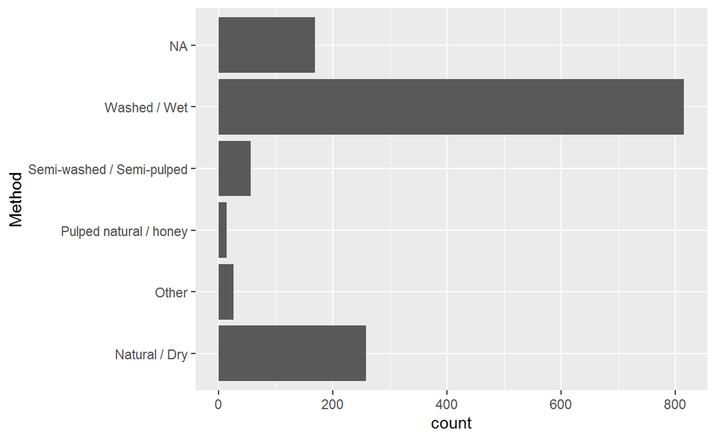

```r
ggplot(coffee)+
  geom_bar(aes(processing_method))+
  labs(x='Method')+
  coord_flip()
```

### Removing NA values

We can remove them by

```r
coffee2<-coffee %>% filter(processing_method!='NA')
```

We can make a density graph to show the relationship between the number of bags tested and the processing method used for them. We have five processing methods.

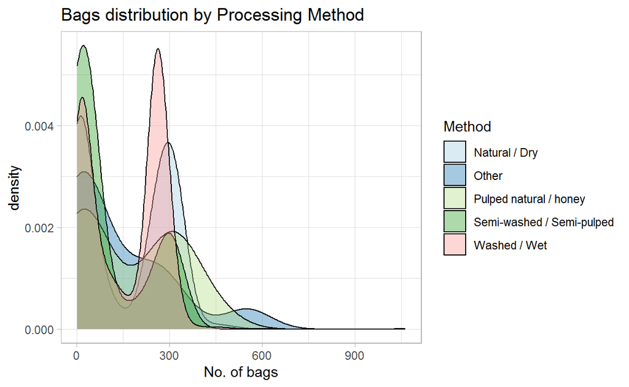

```r
ggplot(coffee2,aes( x = number_of_bags,fill=processing_method) ) +
  geom_density(alpha = 0.4)+
  labs(title='Bags distribution by Processing Method',x="No. of bags",fill="Method")+
  scale_fill_brewer(palette="Paired")+
  theme_light()
```

We can further observe this relationship by calculating mean number of bags per processing method, which gives us

```r
coffee2%>% group_by(processing_method)%>%
  summarize(avgbags=round(mean(number_of_bags),2))
```

```
# A tibble: 5 x 2
  processing_method         avgbags
  <chr>                       <dbl>
1 Natural / Dry               157.
2 Other                       129.
3 Pulped natural / honey      167.
4 Semi-washed / Semi-pulped    94.7
5 Washed / Wet                157.
```

For 1 Numerical and 1 Categorical variable pair, I will use Processing Method and Total Cup Points:

1. Exploring variables

```r
glimpse(coffee_ratings$total_cup_points)
```

```
 num [1:1339] 90.6 89.9 89.8 89 88.8 ...
```

```r
glimpse(coffee_ratings$processing_method)
```

```
 chr [1:1339] "Washed / Wet" "Washed / Wet" NA "Natural / Dry" ...
```

2. For each processing method, we wanted to compute the centrality and spread. Let’s give it a try.

```r
na.omit(coffee_ratings) %>%
    group_by(processing_method) %>%
    summarize(mean_cup_points = mean(total_cup_points), sd_cup_points = sd(total_cup_points))
```

```
# A tibble: 4 x 3
  processing_method      mean_cup_points sd_cup_points
  <chr>                            <dbl>         <dbl>
1 Natural / Dry                     82.5          1.36
2 Other                             77.9          8.54
3 Pulped natural / honey            83.6          1.70
4 Washed / Wet                      82.4          1.52
```

We can clearly see that the spread of Other processing method is quite higher than the all other given processing methods of coffee.

3.To visualize the relationship between these two variables we will use Boxplot.

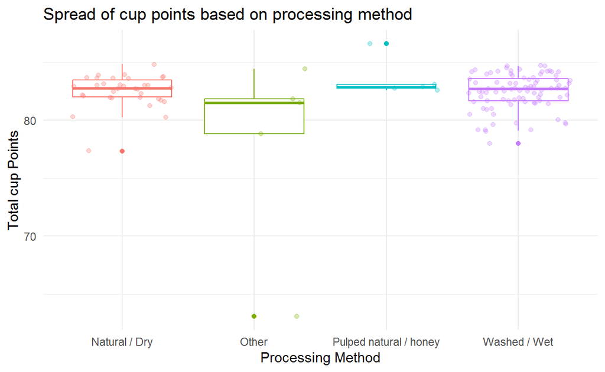

```r
ggplot(na.omit(coffee_ratings),aes(processing_method,total_cup_points,color = processing_method))+
  geom_boxplot(show.legend = FALSE)+
  geom_jitter(alpha = 0.3,show.legend = FALSE)+
  theme_minimal()+
  labs(title = "Spread of cup points based on processing method")+
  xlab("Processing Method")+
  ylab("Total cup Points")
```

4. We can now analyze the centrality and spread of a continuous variable, both univariately and bivariately with respect to a categorical variable.

### For 1 Numerical and 1 Categorical variable pair, I I am using Species and Flavor:

1. To visualize the relationship between these two variables we will use Boxplot.

```r
table1<-data.frame(table(coffee_ratings$flavor,coffee_ratings$species))

colnames(table1)<-c('flavor','species', 'Count')
head(table1,5)
```

```
  flavor species Count
1      0 Arabica     1
2   6.08 Arabica     1
3   6.17 Arabica     2
4   6.33 Arabica     3
5   6.42 Arabica     1
```

```r
coffee_ratings_clean_flavor <- coffee_ratings %>%
  drop_na(flavor)
```

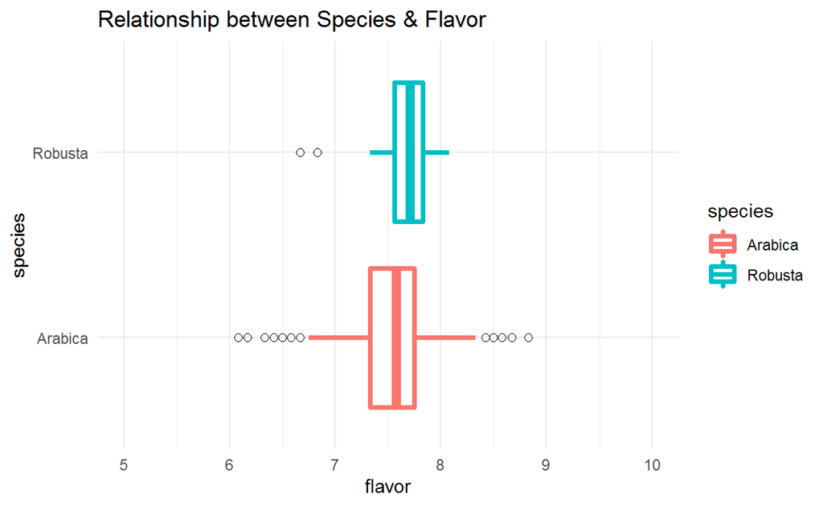

```r
ggplot(coffee_ratings,aes(flavor,species,color= species)) + xlim(5,10) +
  geom_boxplot( size=1.3,
                outlier.shape = 1,
                outlier.color = "black",
                outlier.size  = 2)+
labs(x="flavor",y="species",title= "Relationship between Species & Flavor") +
  theme_minimal()
```

### bivariate analysis between categorical and numerical variable

For our bivariate analysis we will be using grading date and total cup points variables.

1. First we will need to calculate year from grading year to analyse it.

```r
coffee_ratings$'year' <-  (as.factor(str_sub(trimws(coffee_ratings$grading_date,"r"), -4,-1)))
```

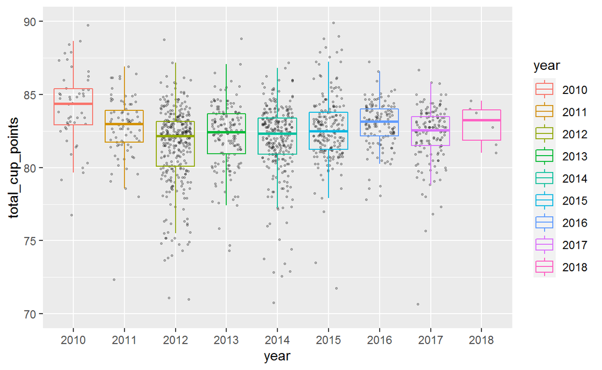

```r
coffee_ratings %>%
  ggplot(aes(x=year, y=total_cup_points)) +
  geom_jitter(height=0, alpha=0.25, size=0.5, width=0.3) +
  geom_boxplot(alpha=0, aes(colour =year))+ylim(70, 90)
```

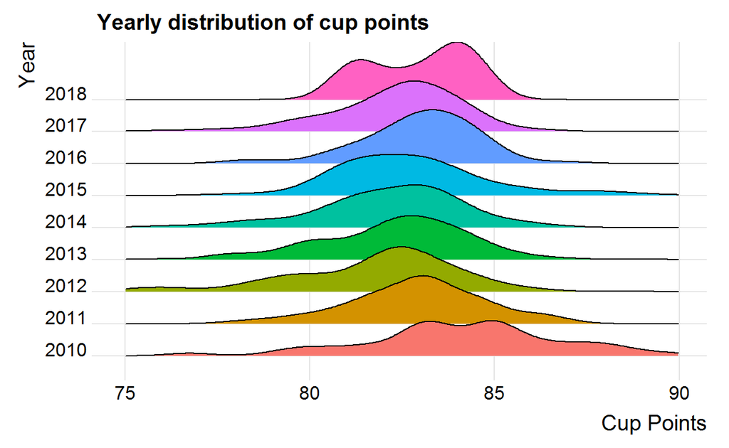

```r
ggplot(coffee_ratings, aes(x = total_cup_points, y = year, fill = year)) +
  geom_density_ridges() +
  theme_ridges() +
  theme(legend.position = "none") + xlim(75, 90)+
  labs(x="Cup Points",y="Year",title= "Yearly distribution of cup points")
```

> As can be seen from the graph for year 2010 has the most spread of cup points and is bimodal distribution. For year 2011 to 2017 the peak is concentrated between 82-84 cup points and the distribution is unimodal. But for year 2018 the distribution is again bimodal.
[^1]: A-Za-z